# Praca domowa nr 3

Agata Makarewicz

5 11 2019

## Wykres do poprawy

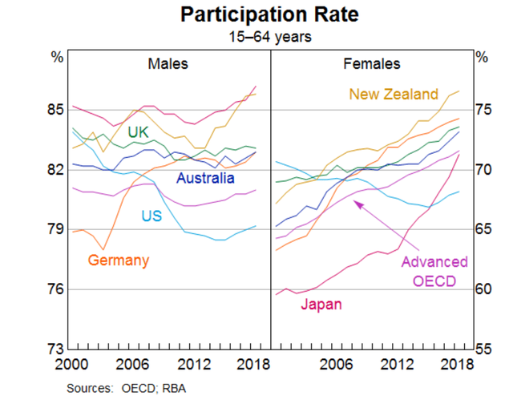

Wykres przedstawia zmiany współczynnika aktywności zawodowej ludności wybranych państw świata w latach 2000-2018, z podziałem względem płci.

Na wykresie, linia podpisana OECD pokazuje średnią wartość wskaźnika państw należących do OECD, czyli Organizacji Współpracy Gospodarczej i Rozwoju, skupiającej 36 wysoko rozwiniętych, demokratycznych krajów.

Wykres nie zaczyna się od 0, chociaż przy tak dużych wartościach procentowych jest to zrozumiałe. Zaburzona jest skala osi y - jedna z nich obejmuje wartosci 73-88 %, gdzie kolejne linie oznaczają wartości różniące sie o 3 %, podczas gdy druga z nich wartosci 55-80 %, ze skokiem co 5 %. Pokazanie tych dwóch wykresów obok siebie, z takimi skalami, oraz z liniami na tym samym poziomie, lecz oznaczającymi różne wartości, może łatwo wprowadzic obserwatora w błąd. Wykres sugeruje, że wskaźniki akywności zawodowej mężczyzn i kobiet są w miare na tym samym poziomie, lub tez minimalnie różnią się, podczas gdy tak naprawdę róznica jest znaczna, w niektórych państwach rzędu 15-20 %, co będzie widoczne na poprawionym wykresie.

Dane do wykresu zostały pobrane ze strony OECD: https://stats.oecd.org/index.aspx?queryid=64197#.

## Przygotowanie danych

```r
# wczytanie danych
data <- read.csv2('data.csv',sep=",")

# wybranie danych potrzebnych do wykresów
data <- data%>%
  select(Country,Sex,Time,Value)
data <- transform(data, Value = as.numeric(Value))

# mężczyźni
data_men <- data%>%
  filter(Sex=="Men")%>%
  ungroup()%>%
  select(-Sex)

# kobiety
data_women <- data%>%
  filter(Sex=="Women")%>%
  ungroup()%>%
  select(-Sex)

# lista wszystkich państw
countries <- t(unique(data["Country"]))

# lata
years <- unique(data["Time"])

# przekształcamy dane, tak aby każda kolumna odpowiadała innemu państwu, wiersze to lata

# mezczyzni
a <- 1
b <- dim(years)[1]
data_final_men <- years
while (b<=dim(data_men)[1]){
  data_temp <- slice(data_men["Value"],a:b)
  data_final_men <- cbind(data_final_men,data_temp)
  a <- a+19
  b <- b+19
}
colnames(data_final_men)[2:4] <- countries[1:3]
colnames(data_final_men)[5:8] <- c("New.Zealand","UK","US","OECD")

# kobiety
a <- 1
b <- dim(years)[1]
data_final_women <- years
while (b<=dim(data_women)[1]){
  data_temp <- slice(data_women["Value"],a:b)
  data_final_women <- cbind(data_final_women,data_temp)
  a <- a+19
  b <- b+19
}
colnames(data_final_women)[2:4] <- countries[1:3]
colnames(data_final_women)[5:8] <- c("New.Zealand","UK","US","OECD")
```

## Poprawiony wykres

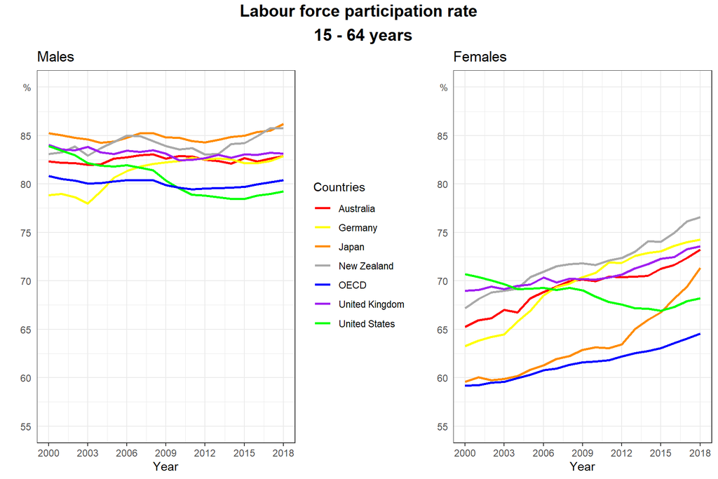

```r
# ustalamy podziałkę i etykiety na osiach
y_breaks <- seq(55,90, by=5)
y_labels <- c(y_breaks[1:7],"%")
x_breaks <- seq(2000,2018,by=3)

# wykres dla mężczyzn
plot1 <- ggplot(data_final_men, aes(x=Time)) +

  # dodajemy linię dla każdego z państw, przypisujemy nazwę do której później przypisany zostanie kolor
  geom_line(aes(y = Australia, col="Australia"),  size=1) +
  geom_line(aes(y = Germany,  col="Germany"),size=1)+
  geom_line(aes(y = Japan,  col="Japan"), size=1)+
  geom_line(aes(y = New.Zealand, col="New Zealand"), size=1)+
  geom_line(aes(y = UK, col="United Kingdom"), size=1)+
  geom_line(aes(y = US, col="United States"), size=1)+
  geom_line(aes(y = OECD, col="OECD"), size=1)+

  # ustalamy podziałkę i skalę osi
  scale_x_continuous(breaks = x_breaks)+
  scale_y_continuous(limits=c(55,90),
                     breaks = y_breaks,
                     labels = y_labels)+

  # ustalamy etykiety osi i tytuł
  ylab("")+
  xlab("Year")+
  ggtitle("Males")+

  # dodajemy legendę
  scale_color_manual(name="Countries",
                     values=c("Australia"="red",
                              "Germany"="yellow",
                              "Japan"="darkorange",
                              "New Zealand"="darkgrey",
                              "United Kingdom"="purple",
                              "United States"="green",
                              "OECD"="blue"))+

  # białe tło
  theme_bw()+

  # usuwamy kreseczki na osi y
  theme(axis.ticks.y=element_blank())



# analogicznie jak w wykresie pierwszym, pomijamy tworzenie legendy bo jest ona taka sama jak na pierwszym wykresie

plot2 <- ggplot(data_final_women, aes(x=Time)) +

  geom_line(aes(y = Australia), color = "red", size=1) +
  geom_line(aes(y = Germany), color="yellow",size=1)+
  geom_line(aes(y = Japan), color = "darkorange", size=1)+
  geom_line(aes(y = New.Zealand), color = "darkgrey", size=1)+
  geom_line(aes(y = UK), color = "purple", size=1)+
  geom_line(aes(y = US), color = "green", size=1)+
  geom_line(aes(y = OECD ), color = "blue", size=1)+

  scale_x_continuous(breaks = x_breaks)+
  scale_y_continuous(limits=c(55,90),
                     breaks = y_breaks,
                     labels = y_labels)+

  ylab("")+
  xlab("Year")+
  ggtitle("Females")+

  theme_bw()+

  theme(axis.ticks.y=element_blank())

# ustalenie układu wykresów, z legendą po środku, dodanie głównego tytułu

grid.arrange(plot1, plot2, top=textGrob("Labour force participation rate
  15 - 64 years", gp=gpar(fontsize=15,font=2)), nrow=1, widths = c(0.58, 0.42))
```